# HW08 - Instrumental Variables (due November 23rd)

In this homework you will practice with running IV regressions with python. You will investigate once more the effect of schooling on earnings, but this time the instrument for education you will use is college proximity to individuals houses (reference paper by [Card, 1993](https://davidcard.berkeley.edu/papers/geo_var_schooling.pdf)).

More in detail, there are two instruments that can be exploited in this context. Both are binary variables taking value 1 if either a 2-years or 4-years college is present in the area where the individual lives.

```python
import pandas as pd
import matplotlib.pyplot as plt
import seaborn as sns
import statsmodels.formula.api as smf
from linearmodels.iv import IV2SLS
from statsmodels.iolib.summary2 import summary_col
import warnings
warnings.filterwarnings('ignore', category=FutureWarning)
warnings.filterwarnings('ignore', category=DeprecationWarning)
warnings.filterwarnings = lambda *a, **kw: None

df = pd.read_stata('http://www.stata.com/data/jwooldridge/eacsap/card.dta')
pd.read_stata('http://www.stata.com/data/jwooldridge/eacsap/card.dta', iterator=True).variable_labels()
```

```
{'id': '',
 'nearc2': '=1 if near 2 yr college, 1966',
 'nearc4': '=1 if near 4 yr college, 1966',
 'educ': 'years of schooling, 1976',
 'age': 'in years',
 'fatheduc': "father's schooling",
 'motheduc': "mother's schooling",
 'weight': 'NLS sampling weight, 1976',
 'momdad14': '=1 if live with mom, dad at 14',
 'sinmom14': '=1 if with single mom at 14',
 'step14': '=1 if with step parent at 14',
 'reg661': 'regional dummy, 1966',
 'reg662': '',
 'reg663': '',
 'reg664': '',
 'reg665': '',
 'reg666': '',
 'reg667': '',
 'reg668': '',
 'reg669': '',
 'south66': '=1 if in south in 1966',
 'black': '=1 if black',
 'smsa': '=1 in in SMSA, 1976',
 'south': '=1 if in south, 1976',
 'smsa66': '=1 if in SMSA, 1966',
 'wage': 'hourly wage in cents, 1976',
 'enroll': '=1 if enrolled in school, 1976',
 'kww': 'knowledge world of work score',
 'iq': 'IQ score',
 'married': '=1 if married, 1976',
 'libcrd14': '=1 if lib. card in home at 14',
 'exper': 'age - educ - 6',
 'lwage': 'log(wage)',
 'expersq': 'exper^2'}
```

```python
df = df.dropna(subset=['lwage', 'educ', 'black', 'south', 'smsa', 'motheduc', 'smsa66', 'iq', 'libcrd14'])
df.head()
```

|  | id | nearc2 | nearc4 | educ | age | fatheduc | motheduc | weight | momdad14 | sinmom14 | ... | smsa66 | wage | enroll | kww | iq | married | libcrd14 | exper | lwage | expersq |
| --- | --- | --- | --- | --- | --- | --- | --- | --- | --- | --- | --- | --- | --- | --- | --- | --- | --- | --- | --- | --- | --- |
| 1 | 3 | 0 | 0 | 12 | 27 | 8.0 | 8.0 | 380166.0 | 1 | 0 | ... | 1 | 481 | 0 | 35.0 | 93.0 | 1.0 | 1.0 | 9 | 6.175867 | 81 |
| 2 | 4 | 0 | 0 | 12 | 34 | 14.0 | 12.0 | 367470.0 | 1 | 0 | ... | 1 | 721 | 0 | 42.0 | 103.0 | 1.0 | 1.0 | 16 | 6.580639 | 256 |
| 3 | 5 | 1 | 1 | 11 | 27 | 11.0 | 12.0 | 380166.0 | 1 | 0 | ... | 1 | 250 | 0 | 25.0 | 88.0 | 1.0 | 1.0 | 10 | 5.521461 | 100 |
| 4 | 6 | 1 | 1 | 12 | 34 | 8.0 | 7.0 | 367470.0 | 1 | 0 | ... | 1 | 729 | 0 | 34.0 | 108.0 | 1.0 | 0.0 | 16 | 6.591674 | 256 |
| 5 | 7 | 1 | 1 | 12 | 26 | 9.0 | 12.0 | 380166.0 | 1 | 0 | ... | 1 | 500 | 0 | 38.0 | 85.0 | 1.0 | 1.0 | 8 | 6.214608 | 64 |

5 rows × 34 columns

### OLS

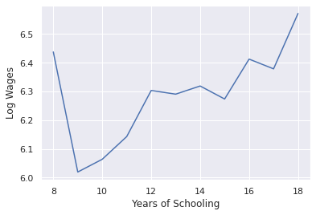

```python
##plot log wages against education
sns.set_theme()
plot = sns.lineplot(data=df, y ='lwage', x='educ', ci=None)
plot.set(xlabel='Years of Schooling', ylabel='Log Wages')
plt.show()
```

```python
##Regress log wages (lwage) against education and include controls, use robust standard errors.

ols = smf.ols('lwage ~ educ + black + south + smsa + motheduc + smsa66 + iq + libcrd14', df).fit(cov_type = 'hc1')
ols.summary()
```

OLS Regression Results

| Dep. Variable: | lwage | R-squared: | 0.115 |
| --- | --- | --- | --- |
| Model: | OLS | Adj. R-squared: | 0.111 |
| Method: | Least Squares | F-statistic: | 29.35 |
| Date: | Mon, 15 Nov 2021 | Prob (F-statistic): | 1.83e-43 |
| Time: | 16:18:01 | Log-Likelihood: | -916.49 |
| No. Observations: | 1875 | AIC: | 1851. |
| Df Residuals: | 1866 | BIC: | 1901. |
| Df Model: | 8 |  |  |
| Covariance Type: | hc1 |  |  |

|  | coef | std err | z | P>\|z\| | [0.025 | 0.975] |
| --- | --- | --- | --- | --- | --- | --- |
| Intercept | 5.7249 | 0.087 | 66.082 | 0.000 | 5.555 | 5.895 |
| educ | 0.0271 | 0.005 | 5.388 | 0.000 | 0.017 | 0.037 |
| black | -0.1539 | 0.031 | -4.916 | 0.000 | -0.215 | -0.093 |
| south | -0.0911 | 0.021 | -4.336 | 0.000 | -0.132 | -0.050 |
| smsa | 0.1315 | 0.027 | 4.931 | 0.000 | 0.079 | 0.184 |
| motheduc | 0.0027 | 0.004 | 0.695 | 0.487 | -0.005 | 0.010 |
| smsa66 | 0.0454 | 0.025 | 1.817 | 0.069 | -0.004 | 0.094 |
| iq | 0.0013 | 0.001 | 1.582 | 0.114 | -0.000 | 0.003 |
| libcrd14 | -0.0145 | 0.022 | -0.673 | 0.501 | -0.057 | 0.028 |

| Omnibus: | 41.283 | Durbin-Watson: | 1.876 |
| --- | --- | --- | --- |
| Prob(Omnibus): | 0.000 | Jarque-Bera (JB): | 49.748 |
| Skew: | -0.293 | Prob(JB): | 1.57e-11 |
| Kurtosis: | 3.541 | Cond. No. | 911. |

Notes:  
[1] Standard Errors are heteroscedasticity robust (HC1)

**What are other possible confunders?**

Unobsered skills or ability

### 2SLS

You will use only on proximity to a 4-years college ($nearc4$) as instrument.

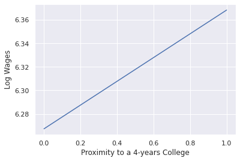

```python
##plot log wages against nearc4
plot = sns.lineplot(data=df, y ='lwage', x='nearc4', ci=None)
plot.set(xlabel='Proximity to a 4-years College', ylabel='Log Wages')
plt.show()
```

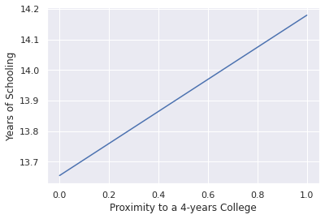

```python
##plot education against nearc4
plot = sns.lineplot(data=df, y ='educ', x='nearc4', ci=None)
plot.set(xlabel='Proximity to a 4-years College', ylabel='Years of Schooling')
plt.show()
```

**If you run an IV regression of log wages on education, using college proximity as an instrument for education, what would you expect the sign of the coefficient on education to be? Why?**

The figures suggest that both the first stage and the reduced form coefficients are positive, implying that we can expect a positive sign from a ratio of the two, that is for the IV coefficient.

```python
##run a regression of education on nearc4, adding the controls you selected before and using robust standard errors
fs = smf.ols('educ ~ nearc4 + black + south + smsa + motheduc + smsa66 + iq + libcrd14', df).fit(cov_type = 'hc1')
```

```python
##predict education from the previous regression
df['educhat'] = fs.predict()
df['educhat'].head()
```

```
1    12.539486
2    13.871337
3    13.218784
4    13.166579
5    13.015220
Name: educhat, dtype: float64
```

```python
##run a regression of log wages on education and controls using robust standard errors
twosls = smf.ols('lwage ~ educhat+ black + south + smsa + motheduc + smsa66 + iq + libcrd14', df).fit(cov_type = 'hc1')
```

```python
##compare the 2sls and ols estimates
print(summary_col([ols, twosls], float_format='%0.3f',  info_dict={'N':lambda x: "{0:d}".format(int(x.nobs))}, regressor_order=['educ', 'educhat']))
```

```
===============================
               lwage I lwage II
-------------------------------
educ           0.027
               (0.005)
educhat                0.054
                       (0.060)
Intercept      5.725   5.603
               (0.087) (0.284)
black          -0.154  -0.168
               (0.031) (0.046)
iq             0.001   -0.001
               (0.001) (0.004)
libcrd14       -0.014  -0.031
               (0.022) (0.043)
motheduc       0.003   -0.002
               (0.004) (0.010)
smsa           0.131   0.123
               (0.027) (0.033)
smsa66         0.045   0.052
               (0.025) (0.029)
south          -0.091  -0.098
               (0.021) (0.027)
R-squared      0.115   0.101
R-squared Adj. 0.111   0.097
N              1875    1875
===============================
Standard errors in parentheses.
```

**What do you think the difference in the estimates is due to?**

The IV coefficient is larger than the OLS one, suggesting that the OLS estimate is biased downward. This can have three different explanations:

1. There is an negative omitted variable bias in the OLS estimate
2. There is attenuation bias in the OLS estimate due to measurament error in the explanatory variable (education)
3. The effect of education is larger for compliers, that is individuals who would shift their level of education depending on the value of the instrument

### IV analysis

```python
##use IV2sls to run the regression of log wages on education. using college proximity as an instrument for education
##add the same controls as before and use robust standard errors

from linearmodels.iv import IV2SLS
import statsmodels.api as sm

exog = sm.add_constant(df[['black', 'south', 'smsa', 'motheduc', 'smsa66', 'iq', 'libcrd14']])
iv2sls = IV2SLS(df.lwage, exog, df.educ, df.nearc4).fit(cov_type='robust')
iv2sls
```

IV-2SLS Estimation Summary

| Dep. Variable: | lwage | R-squared: | 0.1004 |
| --- | --- | --- | --- |
| Estimator: | IV-2SLS | Adj. R-squared: | 0.0966 |
| No. Observations: | 1875 | F-statistic: | 207.54 |
| Date: | Mon, Nov 15 2021 | P-value (F-stat) | 0.0000 |
| Time: | 16:42:46 | Distribution: | chi2(8) |
| Cov. Estimator: | robust |  |  |

Parameter Estimates

|  | Parameter | Std. Err. | T-stat | P-value | Lower CI | Upper CI |
| --- | --- | --- | --- | --- | --- | --- |
| const | 5.6027 | 0.2856 | 19.617 | 0.0000 | 5.0429 | 6.1625 |
| black | -0.1681 | 0.0458 | -3.6674 | 0.0002 | -0.2579 | -0.0783 |
| south | -0.0982 | 0.0264 | -3.7261 | 0.0002 | -0.1499 | -0.0465 |
| smsa | 0.1229 | 0.0330 | 3.7274 | 0.0002 | 0.0583 | 0.1875 |
| motheduc | -0.0017 | 0.0105 | -0.1657 | 0.8684 | -0.0222 | 0.0188 |
| smsa66 | 0.0518 | 0.0288 | 1.7975 | 0.0723 | -0.0047 | 0.1083 |
| iq | -0.0005 | 0.0042 | -0.1247 | 0.9008 | -0.0087 | 0.0077 |
| libcrd14 | -0.0309 | 0.0427 | -0.7237 | 0.4693 | -0.1147 | 0.0528 |
| educ | 0.0541 | 0.0603 | 0.8969 | 0.3698 | -0.0641 | 0.1724 |

Endogenous: educ  
Instruments: nearc4  
Robust Covariance (Heteroskedastic)  
Debiased: False  
id: 0x7f651261ae80

**Compare the estiamte with the one found at the previous point.**

The estimates are the same because the IV function from linearmodels estimates the coefficient via 2 stage least squares.